# Cyclistic bike-share analysis case study by Dr. Vipul Gohel

#### Introduction and Study Objective

This is the capstone project part of the Google Analytical Certificate Course.

#### Ask

The case study is to Study the pattern of annual member and non-member riders to define the marketing strategy of bringing the non-member into the member program.

The following three questions would help in directing the future marketing Program.

1. How do annual members and casual riders use Cyclistic bikes differently?
2. Why would casual riders buy Cyclistic annual memberships?
3. How can Cyclistic use digital media to influence casual riders to become members? Tool followed:- Excel(Power-Pivot & Power Query), R,

#### Prepare

Data set obtained from the link Data set from Quarter # 2 of 2019 to Quarter # 1 of 2020 were downloaded from the link and stored on the local desktop.

#### Process

Following steps were performed in the R platform, and the final file was extracted for final analysis

1. Made the columns’ name uniform across the file
2. Before merging the files, remove any extra columns that are not common to all files.
3. Merge the column into one file using the full outer join Rename the row from Subscriber/member to Member and Customer / casual to Non-Member
4. Identified the outliers and recorded outliers in a separate column as “Outliers.”
5. Extracted the file as CSV, and the same file was used for the analysis The file was ready to use for the analysis.

#### Pre-Data analysis

we created the following columns

Ride Length in Minutes – This was done by subtracting the ride’s start time from to end time.

1. Weekday – calculated from the start time column
2. Day name – calculated from the start time column
3. Day number – calculated from the start time column
4. Yea-Month-Quarter - calculated from the start time column
5. Similar way Month number, month name and quarters were created

```r
# Load Required Library
require(tidyverse)
require(lubridate)
require(dplyr)
require(here)
require(skimr)
require(janitor)
require(hablar)
require(gapminder)
require(scales)
require(ggrepel)
require(dplyr)
options(warn=-1)
```

#### Load the data files

```r
divvy_tips_2019_Q2<-read.csv("Divvy_Trips_2019_Q2.csv")
divvy_tips_2019_Q3<-read.csv("Divvy_Trips_2019_Q3.csv")
divvy_tips_2019_Q4<-read.csv("Divvy_Trips_2019_Q4.csv")
divvy_tips_2020_Q1<-read.csv("Divvy_Trips_2020_Q1.csv")
```

#### Understanding about the Data

```r
# Review the columns name in each given datasets
colnames(divvy_tips_2019_Q2)
```

```
##  [1] "X01...Rental.Details.Rental.ID"
##  [2] "X01...Rental.Details.Local.Start.Time"
##  [3] "X01...Rental.Details.Local.End.Time"
##  [4] "X01...Rental.Details.Bike.ID"
##  [5] "X01...Rental.Details.Duration.In.Seconds.Uncapped"
##  [6] "X03...Rental.Start.Station.ID"
##  [7] "X03...Rental.Start.Station.Name"
##  [8] "X02...Rental.End.Station.ID"
##  [9] "X02...Rental.End.Station.Name"
## [10] "User.Type"
## [11] "Member.Gender"
## [12] "X05...Member.Details.Member.Birthday.Year"
```

```r
colnames(divvy_tips_2019_Q3)
```

```
##  [1] "trip_id"           "start_time"        "end_time"
##  [4] "bikeid"            "tripduration"      "from_station_id"
##  [7] "from_station_name" "to_station_id"     "to_station_name"
## [10] "usertype"          "gender"            "birthyear"
```

```r
colnames(divvy_tips_2019_Q4)
```

```
##  [1] "trip_id"           "start_time"        "end_time"
##  [4] "bikeid"            "tripduration"      "from_station_id"
##  [7] "from_station_name" "to_station_id"     "to_station_name"
## [10] "usertype"          "gender"            "birthyear"
```

```r
colnames(divvy_tips_2020_Q1)
```

```
##  [1] "ride_id"            "rideable_type"      "started_at"
##  [4] "ended_at"           "start_station_name" "start_station_id"
##  [7] "end_station_name"   "end_station_id"     "start_lat"
## [10] "start_lng"          "end_lat"            "end_lng"
## [13] "member_casual"
```

Each column names and column position need to be uniform across the file before joining the datasets from 2019-Q2 to 2020-Q1

```r
divvy_tips_2019_Q2<-divvy_tips_2019_Q2 %>%
  rename(Rental_ID=X01...Rental.Details.Rental.ID,
         From_Start_Date_Time=X01...Rental.Details.Local.Start.Time,
         To_End_Date_Time=X01...Rental.Details.Local.End.Time,
         Rental_Bike_ID=X01...Rental.Details.Bike.ID,
         Rental_Duration_Second=X01...Rental.Details.Duration.In.Seconds.Uncapped,
         Start_Station_ID=X03...Rental.Start.Station.ID,
         Start_Station_Name=X03...Rental.Start.Station.Name,
         End_Station_ID=X02...Rental.End.Station.ID,
         End_Station_Name=X02...Rental.End.Station.Name,
         User_Type=User.Type,
         Gender=Member.Gender,
         Birth_Year=X05...Member.Details.Member.Birthday.Year)

divvy_tips_2019_Q3<-divvy_tips_2019_Q3 %>%
  rename(Rental_ID=trip_id,
         From_Start_Date_Time=start_time,
         To_End_Date_Time=end_time,
         Rental_Bike_ID=bikeid,
         Rental_Duration_Second=tripduration,
         Start_Station_ID=from_station_id,
         Start_Station_Name=from_station_name,
         End_Station_ID=to_station_id,
         End_Station_Name=to_station_name,
         User_Type=usertype,
         Gender=gender,
         Birth_Year=birthyear)

divvy_tips_2019_Q4<-divvy_tips_2019_Q4 %>%
  rename(Rental_ID=trip_id,
         From_Start_Date_Time=start_time,
         To_End_Date_Time=end_time,
         Rental_Bike_ID=bikeid,
         Rental_Duration_Second=tripduration,
         Start_Station_ID=from_station_id,
         Start_Station_Name=from_station_name,
         End_Station_ID=to_station_id,
         End_Station_Name=to_station_name,
         User_Type=usertype,
         Gender=gender,
         Birth_Year=birthyear)

divvy_tips_2020_Q1<-divvy_tips_2020_Q1 %>%
  rename(Rental_ID=ride_id,
         From_Start_Date_Time=started_at,
         To_End_Date_Time=ended_at,
         Start_Station_Name=start_station_name,
         Start_Station_ID=start_station_id,
         End_Station_Name=end_station_name,
         End_Station_ID=end_station_id,
         User_Type=member_casual)
```

```r
# Remove the columns that are not required

divvy_tips_2019_Q2<-divvy_tips_2019_Q2 %>%
  select(-c(Rental_ID,Rental_Bike_ID,Rental_Duration_Second,
            Gender, Birth_Year))

divvy_tips_2019_Q3<-divvy_tips_2019_Q3 %>%
  select(-c(Rental_ID,Rental_Bike_ID,Rental_Duration_Second,
            Gender,Birth_Year))

divvy_tips_2019_Q4<-divvy_tips_2019_Q4 %>%
  select(-c(Rental_ID,Rental_Bike_ID,Rental_Duration_Second,
            Gender,Birth_Year))

divvy_tips_2020_Q1<-divvy_tips_2020_Q1 %>%
  select(c(From_Start_Date_Time,To_End_Date_Time,
           Start_Station_ID,Start_Station_Name,End_Station_ID,
           End_Station_Name,User_Type))
```

```r
# Review the data structure of the given dataset
str(divvy_tips_2019_Q2)
```

```
## 'data.frame':    1108163 obs. of  7 variables:
##  $ From_Start_Date_Time: chr  "2019-04-01 00:02:22" "2019-04-01 00:03:02" "2019-04-01 00:11:07" "2019-04-01 00:13:01" ...
##  $ To_End_Date_Time    : chr  "2019-04-01 00:09:48" "2019-04-01 00:20:30" "2019-04-01 00:15:19" "2019-04-01 00:18:58" ...
##  $ Start_Station_ID    : int  81 317 283 26 202 420 503 260 211 211 ...
##  $ Start_Station_Name  : chr  "Daley Center Plaza" "Wood St & Taylor St" "LaSalle St & Jackson Blvd" "McClurg Ct & Illinois St" ...
##  $ End_Station_ID      : int  56 59 174 133 129 426 500 499 211 211 ...
##  $ End_Station_Name    : chr  "Desplaines St & Kinzie St" "Wabash Ave & Roosevelt Rd" "Canal St & Madison St" "Kingsbury St & Kinzie St" ...
##  $ User_Type           : chr  "Subscriber" "Subscriber" "Subscriber" "Subscriber" ...
```

```r
str(divvy_tips_2019_Q3)
```

```
## 'data.frame':    1640718 obs. of  7 variables:
##  $ From_Start_Date_Time: chr  "2019-07-01 00:00:27" "2019-07-01 00:01:16" "2019-07-01 00:01:48" "2019-07-01 00:02:07" ...
##  $ To_End_Date_Time    : chr  "2019-07-01 00:20:41" "2019-07-01 00:18:44" "2019-07-01 00:27:42" "2019-07-01 00:27:10" ...
##  $ Start_Station_ID    : int  117 381 313 313 168 300 168 313 43 43 ...
##  $ Start_Station_Name  : chr  "Wilton Ave & Belmont Ave" "Western Ave & Monroe St" "Lakeview Ave & Fullerton Pkwy" "Lakeview Ave & Fullerton Pkwy" ...
##  $ End_Station_ID      : int  497 203 144 144 62 232 62 144 195 195 ...
##  $ End_Station_Name    : chr  "Kimball Ave & Belmont Ave" "Western Ave & 21st St" "Larrabee St & Webster Ave" "Larrabee St & Webster Ave" ...
##  $ User_Type           : chr  "Subscriber" "Customer" "Customer" "Customer" ...
```

```r
str(divvy_tips_2019_Q4)
```

```
## 'data.frame':    704054 obs. of  7 variables:
##  $ From_Start_Date_Time: chr  "2019-10-01 00:01:39" "2019-10-01 00:02:16" "2019-10-01 00:04:32" "2019-10-01 00:04:32" ...
##  $ To_End_Date_Time    : chr  "2019-10-01 00:17:20" "2019-10-01 00:06:34" "2019-10-01 00:18:43" "2019-10-01 00:43:43" ...
##  $ Start_Station_ID    : int  20 19 84 313 210 156 84 156 156 336 ...
##  $ Start_Station_Name  : chr  "Sheffield Ave & Kingsbury St" "Throop (Loomis) St & Taylor St" "Milwaukee Ave & Grand Ave" "Lakeview Ave & Fullerton Pkwy" ...
##  $ End_Station_ID      : int  309 241 199 290 382 226 142 463 463 336 ...
##  $ End_Station_Name    : chr  "Leavitt St & Armitage Ave" "Morgan St & Polk St" "Wabash Ave & Grand Ave" "Kedzie Ave & Palmer Ct" ...
##  $ User_Type           : chr  "Subscriber" "Subscriber" "Subscriber" "Subscriber" ...
```

```r
str(divvy_tips_2020_Q1)
```

```
## 'data.frame':    426887 obs. of  7 variables:
##  $ From_Start_Date_Time: chr  "2020-01-21 20:06:59" "2020-01-30 14:22:39" "2020-01-09 19:29:26" "2020-01-06 16:17:07" ...
##  $ To_End_Date_Time    : chr  "2020-01-21 20:14:30" "2020-01-30 14:26:22" "2020-01-09 19:32:17" "2020-01-06 16:25:56" ...
##  $ Start_Station_ID    : int  239 234 296 51 66 212 96 96 212 38 ...
##  $ Start_Station_Name  : chr  "Western Ave & Leland Ave" "Clark St & Montrose Ave" "Broadway & Belmont Ave" "Clark St & Randolph St" ...
##  $ End_Station_ID      : int  326 318 117 24 212 96 212 212 96 100 ...
##  $ End_Station_Name    : chr  "Clark St & Leland Ave" "Southport Ave & Irving Park Rd" "Wilton Ave & Belmont Ave" "Fairbanks Ct & Grand Ave" ...
##  $ User_Type           : chr  "member" "member" "member" "member" ...
```

```r
# Check Distinct User Type in each dataset
unique(divvy_tips_2019_Q2$User_Type)
```

```
## [1] "Subscriber" "Customer"
```

```r
unique(divvy_tips_2019_Q3$User_Type)
```

```
## [1] "Subscriber" "Customer"
```

```r
unique(divvy_tips_2019_Q4$User_Type)
```

```
## [1] "Subscriber" "Customer"
```

```r
unique(divvy_tips_2020_Q1$User_Type)
```

```
## [1] "member" "casual"
```

```r
# Uniform Rows name across the dataset for User Type
divvy_tips_2019_Q2$User_Type<-recode(divvy_tips_2019_Q2$User_Type,
                                     "Subscriber" ="Member",
                                     "Customer" ="Not Member")

divvy_tips_2019_Q3$User_Type<-recode(divvy_tips_2019_Q3$User_Type,
                                     "Subscriber" ="Member",
                                     "Customer" ="Not Member")

divvy_tips_2019_Q4$User_Type<-recode(divvy_tips_2019_Q4$User_Type,
                                     "Subscriber" ="Member",
                                     "Customer" ="Not Member")

divvy_tips_2020_Q1$User_Type<-recode(divvy_tips_2020_Q1$User_Type,
                                     "member" ="Member",
                                     "casual" ="Not Member")
```

```r
# Combine all four sets of dataset

divvy_tips_2019_2020<-bind_rows(divvy_tips_2019_Q2,divvy_tips_2019_Q3,
                                divvy_tips_2019_Q4,divvy_tips_2020_Q1)
```

```r
# Review the User Type column after modification.
# The member should now be two types only: 'Member' and 'Not Member'

unique(divvy_tips_2019_2020$User_Type)
```

```
## [1] "Member"     "Not Member"
```

```r
# Review the merged datasets

print(str(divvy_tips_2019_2020))
```

```
## 'data.frame':    3879822 obs. of  7 variables:
##  $ From_Start_Date_Time: chr  "2019-04-01 00:02:22" "2019-04-01 00:03:02" "2019-04-01 00:11:07" "2019-04-01 00:13:01" ...
##  $ To_End_Date_Time    : chr  "2019-04-01 00:09:48" "2019-04-01 00:20:30" "2019-04-01 00:15:19" "2019-04-01 00:18:58" ...
##  $ Start_Station_ID    : int  81 317 283 26 202 420 503 260 211 211 ...
##  $ Start_Station_Name  : chr  "Daley Center Plaza" "Wood St & Taylor St" "LaSalle St & Jackson Blvd" "McClurg Ct & Illinois St" ...
##  $ End_Station_ID      : int  56 59 174 133 129 426 500 499 211 211 ...
##  $ End_Station_Name    : chr  "Desplaines St & Kinzie St" "Wabash Ave & Roosevelt Rd" "Canal St & Madison St" "Kingsbury St & Kinzie St" ...
##  $ User_Type           : chr  "Member" "Member" "Member" "Member" ...
## NULL
```

```r
# Formating the date columns from character to date and time

divvy_tips_2019_2020$From_Start_Date_Time<-ymd_hms(divvy_tips_2019_2020$From_Start_Date_Time)

divvy_tips_2019_2020$To_End_Date_Time<-ymd_hms(divvy_tips_2019_2020$To_End_Date_Time)
```

For data analysis, we created the new column, ride length in minutes, by subtracting the end time from the trip’s start time.

```r
divvy_tips_2019_2020$Ride_Length_min<-
as.numeric(as.character(difftime(divvy_tips_2019_2020$To_End_Date_Time,divvy_tips_2019_2020$From_Start_Date_Time)/60))
```

We removed the data whose ride length in minutes is less than zero. We used the filter command to consider those whose ride length in minutes is greater than zero.

```r
divvy_tips_2019_2020<-filter(divvy_tips_2019_2020, Ride_Length_min>0)
head(divvy_tips_2019_2020)
```

|  | From_Start_Date_Time | To_End_Date_Time | Start_Station_ID | Start_Station_Name | End_Station_ID | End_Station_Name | User_Type | Ride_Length_min |
| --- | --- | --- | --- | --- | --- | --- | --- | --- |
| 1 | 2019-04-01 00:02:22 | 2019-04-01 00:09:48 | 81 | Daley Center Plaza | 56 | Desplaines St & Kinzie St | Member | 7.433333 |
| 2 | 2019-04-01 00:03:02 | 2019-04-01 00:20:30 | 317 | Wood St & Taylor St | 59 | Wabash Ave & Roosevelt Rd | Member | 17.466667 |
| 3 | 2019-04-01 00:11:07 | 2019-04-01 00:15:19 | 283 | LaSalle St & Jackson Blvd | 174 | Canal St & Madison St | Member | 4.200000 |
| 4 | 2019-04-01 00:13:01 | 2019-04-01 00:18:58 | 26 | McClurg Ct & Illinois St | 133 | Kingsbury St & Kinzie St | Member | 5.950000 |
| 5 | 2019-04-01 00:19:26 | 2019-04-01 00:36:13 | 202 | Halsted St & 18th St | 129 | Blue Island Ave & 18th St | Member | 16.783333 |
| 6 | 2019-04-01 00:19:39 | 2019-04-01 00:23:56 | 420 | Ellis Ave & 55th St | 426 | Ellis Ave & 60th St | Member | 4.283333 |

Visualize the data using the box-pot to understand the distribution pattern and outliers.

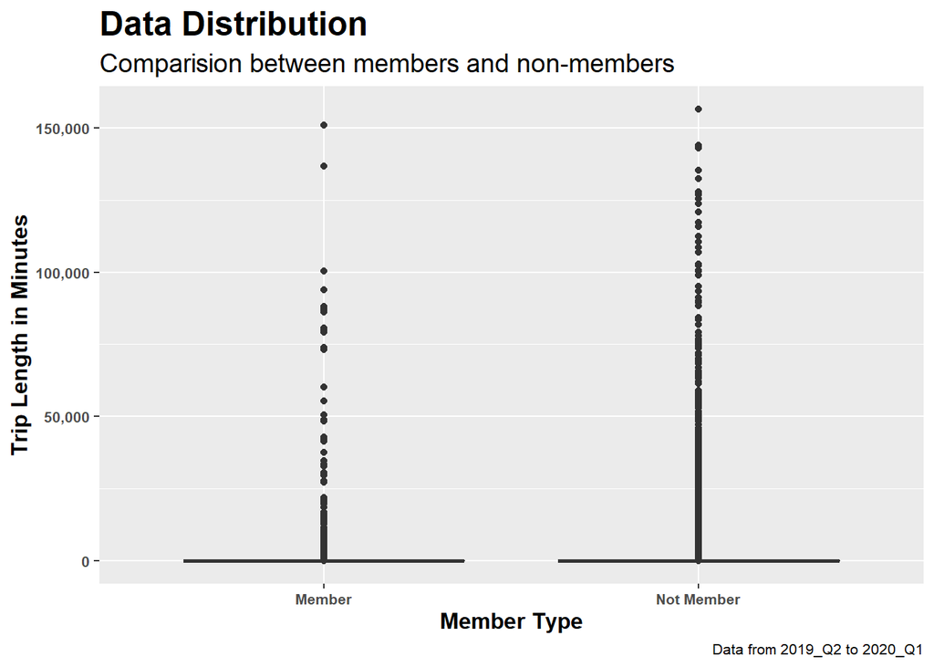

```r
# Graph labeling
graphM<-labs(title = "Data Distribution",
             subtitle= "Comparision between members and non-members",
             caption = "Data from 2019_Q2 to 2020_Q1",
             x = "Member Type",
             y ="Trip Length in Minutes")

# Graph Themes
graphTh<-theme(plot.title = element_text(size=18,face="bold"),
               plot.subtitle = element_text(size=14),
               plot.caption = element_text(size=8),
               axis.title.x = element_text(size=12, face="bold"),
               axis.title.y= element_text(size=12, face="bold"),
               axis.text.x=element_text(size=8,face="bold"),
               axis.text.y=element_text(size=8,face="bold"))

# Box-Plot
options(repr.plot.width=12, repr.plot.height=8)
ggplot(data=divvy_tips_2019_2020)+
  geom_boxplot(mapping = aes(x=User_Type,y=Ride_Length_min))+
  scale_y_continuous(label = scales::comma)+
  graphM +
  graphTh
```

For analysis purposes, we created the columns such as Day of Week, Day Name, Month Number, Month Name, hour, and year from the “From_Start_Date_Time” column.

```r
divvy_tips_2019_2020<- divvy_tips_2019_2020 %>%
  mutate(Day_of_Week = wday(From_Start_Date_Time),
         Day_Name = wday(From_Start_Date_Time,label = TRUE, abbr = FALSE),
         Month_Number=month(From_Start_Date_Time),
         Month_Name =months(From_Start_Date_Time),
         quarter_Number = quarters(From_Start_Date_Time),
         Year = year(From_Start_Date_Time),
         Hour= hour(From_Start_Date_Time))
```

Dataset has many outliers; we will analyze the percentage of outliers in each user type category.

```r
# Quartile one

Q1<-divvy_tips_2019_2020 %>%
  group_by(User_Type) %>%
  summarize(Q1= quantile(Ride_Length_min,probs=0.25))

Q1
```

| User_Type | Q1 |
| --- | --- |
| Member | 6.033333 |
| Not Member | 15.050000 |

```r
# Quartile three

Q3<-divvy_tips_2019_2020 %>%
  group_by(User_Type) %>%
  summarize(Q3= quantile(Ride_Length_min,probs=0.75))
Q3
```

| User_Type | Q3 |
| --- | --- |
| Member | 16.18333 |
| Not Member | 45.10000 |

```r
# Inter Quartile Range

IQR<-divvy_tips_2019_2020 %>%
  group_by(User_Type) %>%
  summarize(IQR= quantile(Ride_Length_min,probs=0.75)-quantile(Ride_Length_min,probs=0.25))
IQR
```

| User_Type | IQR |
| --- | --- |
| Member | 10.15 |
| Not Member | 30.05 |

Apply these calculations to our dataset

```r
# Lower Bound

Lower_Bound<-divvy_tips_2019_2020 %>%
  group_by(User_Type) %>%
  summarize(Lower_Bound= quantile(Ride_Length_min,probs=0.25)-
              1.5*(quantile(Ride_Length_min,probs=0.75)-quantile(Ride_Length_min,probs=0.25)))
Lower_Bound
```

| User_Type | Lower_Bound |
| --- | --- |
| Member | -9.191667 |
| Not Member | -30.025000 |

```r
# Upper Bound

Upper_Bound<-divvy_tips_2019_2020 %>%
  group_by(User_Type) %>%
  summarize(Upper_Bound= quantile(Ride_Length_min,probs=0.75)+
              1.5*(quantile(Ride_Length_min,probs=0.75)-quantile(Ride_Length_min,probs=0.25)))
Upper_Bound
```

| User_Type | Upper_Bound |
| --- | --- |
| Member | 31.40833 |
| Not Member | 90.17500 |

```r
# Combine Lower and Upper Bound

Outlier_prm<-cbind(Lower_Bound,Upper_Bound)
Outlier_prm<-Outlier_prm %>% select(-3)
Outlier_prm
```

| User_Type | Lower_Bound | Upper_Bound |
| --- | --- | --- |
| Member | -9.191667 | 31.40833 |
| Not Member | -30.025000 | 90.17500 |

```r
# Data Merge with Orginal Dataset

divvy_tips_2019_2020<- merge(divvy_tips_2019_2020,Outlier_prm, by ="User_Type", all=TRUE)
```

```r
# Create Outliers column first as Ture and Flase

divvy_tips_2019_2020$Outliers <-
  divvy_tips_2019_2020$Ride_Length_min<= divvy_tips_2019_2020$Lower_Bound | divvy_tips_2019_2020$Ride_Length_min>= divvy_tips_2019_2020$Upper_Bound
```

```r
# Convert Ture and Flase into Yes and No

divvy_tips_2019_2020$Outliers[divvy_tips_2019_2020$Outliers== TRUE]<- "Yes"
divvy_tips_2019_2020$Outliers[divvy_tips_2019_2020$Outliers== FALSE]<- "No"
```

```r
# Check Outliers column, and it should be only two values that is "Yes" and "No".

unique(divvy_tips_2019_2020$Outliers)
```

```
## [1] "No"  "Yes"
```

Dataset has many outliers; we will analyze the percentage of outliers in each user type category.

Data visualization to identify the outliers % within members and not members.

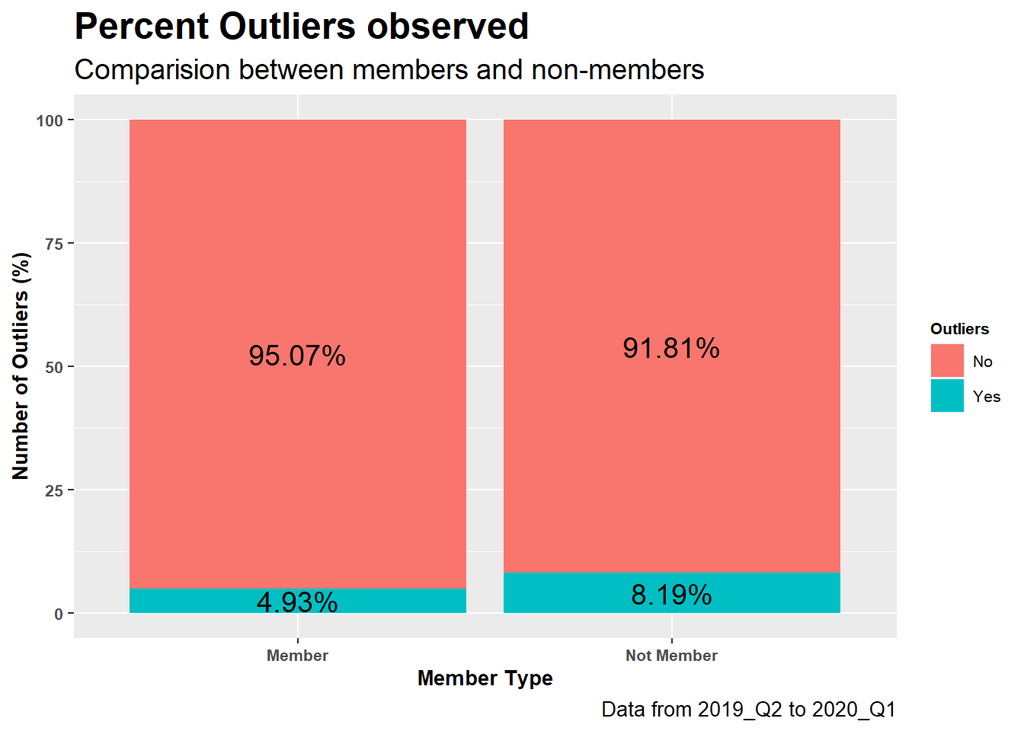

```r
# Graph labeling

graphM1<-labs(title = "Percent Outliers observed",
              subtitle= "Comparision between members and non-members",
              caption = "Data from 2019_Q2 to 2020_Q1",
              x = "Member Type",
              y ="Number of Outliers (%)")

# Graph Theme

graphTh1<-theme(legend.title=element_text(size=8, face="bold"),
                legend.text = element_text(size=8),
                plot.title = element_text(size=18,face="bold"),
                plot.subtitle = element_text(size=14),
                plot.caption = element_text(size=10),
                axis.title.x = element_text(size=10, face="bold"),
                axis.title.y= element_text(size=10, face="bold"),
                axis.text.x=element_text(size=8, face= 'bold'),
                axis.text.y=element_text(size=8, face= 'bold'))

# stacked bar chart

options(repr.plot.width=10, repr.plot.height=8)
divvy_tips_2019_2020 %>%
  count(User_Type,Outliers) %>%
  group_by(User_Type) %>%
  mutate(percnt=prop.table(n)*100) %>%
  ggplot(mapping=aes(User_Type, percnt, fill=Outliers,
                     label = paste0(round(percnt,2), "%")))+
  geom_bar(stat="identity")+
  geom_text(position = position_stack(vjust = .5),
            size= 5)+
  graphM1 +
  graphTh1
```

Total outliers from the members are 4.93%, while 8.19% are observed in the non-members.

We will remove the outliers from “Member” and “Not Member”. We will use the filter command to keep the dataset having the outliers marked as No.

```r
# Remove outliers

divvy_tips_2019_2020<-filter(divvy_tips_2019_2020, Outliers =="No")
```

```r
# review the columns name in the dataset
colnames(divvy_tips_2019_2020)
```

```
##  [1] "User_Type"            "From_Start_Date_Time" "To_End_Date_Time"
##  [4] "Start_Station_ID"     "Start_Station_Name"   "End_Station_ID"
##  [7] "End_Station_Name"     "Ride_Length_min"      "Day_of_Week"
## [10] "Day_Name"             "Month_Number"         "Month_Name"
## [13] "quarter_Number"       "Year"                 "Hour"
## [16] "Lower_Bound"          "Upper_Bound"          "Outliers"
```

#### Data Visualisations

##### Trip Length in Weekdays

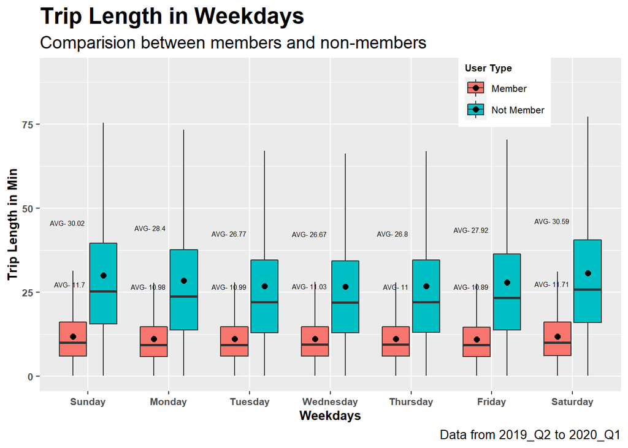

```r
## Trip Length in Weekdays

# Graph labeling

graphM2<- labs(title = "Trip Length in Weekdays",
               subtitle= "Comparision between members and non-members",
               caption = "Data from 2019_Q2 to 2020_Q1",
               x = "Weekdays",
               y ="Trip Length in Min",
               fill="User Type")

# Graph Theme

graphTh2<-theme(legend.position=c(0.80,0.90))


# Box plot Post removal of the Outliers

options(repr.plot.width=15, repr.plot.height=8)
ggplot(data=divvy_tips_2019_2020,
       mapping = aes(x=Day_Name,y=Ride_Length_min, fill=User_Type))+
  geom_boxplot(outlier.shape = NA)+
  stat_summary(fun=mean, geom = "point", size=2,
               position=position_dodge(width=0.75), color="black")+
  stat_summary(fun = mean, geom = "text", col = "black",
               vjust = -8.9, hjust=1.1,size=2,
               aes(label = paste("AVG-", round(..y.., digits = 2))))+
  graphM2+
  graphTh1+
  graphTh2
```

1. Mean trip length was lowered with members compared to non-members.
2. Interestingly, the mean trip length was 3 minutes higher on the weekend with the non-members when the weekend data is compared with Monday to Friday data of the same group.
3. There is no significant difference in mean trip value in minutes observed within members of weekdays data.

##### Number of Trips in 24 hours

[output not shown]

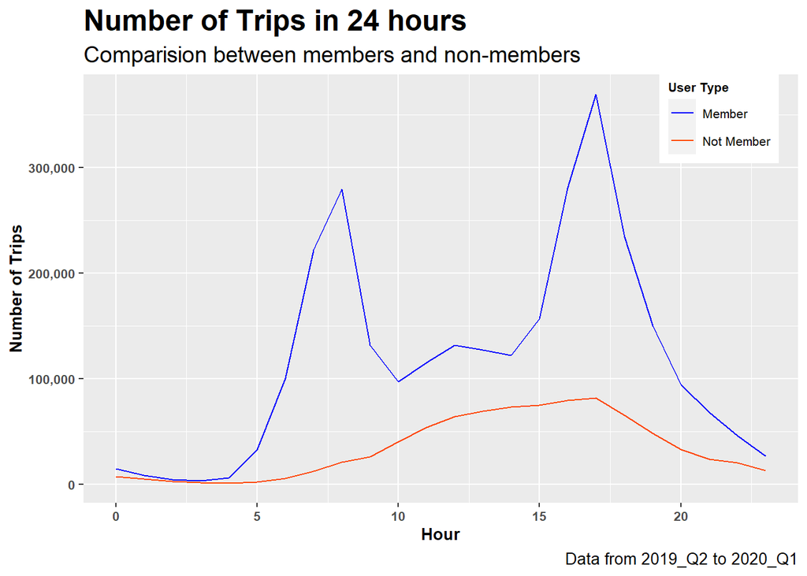

```r
# Graph labeling

graphM3<- labs(title = "Number of Trips in 24 hours",
               subtitle= "Comparision between members and non-members",
               caption = "Data from 2019_Q2 to 2020_Q1",
               x = "Hour",
               y ="Number of Trips",
               color="User Type")

# Graph Theme

graphTh3<-theme(legend.position=c(0.89,0.90))

# Line chart - Number of trips in 24hours

divvy_tips_2019_2020 %>% group_by(Hour,User_Type) %>%
  summarise(Total_Rides = n()) %>%
  ggplot(mapping = aes(x=Hour, y=Total_Rides,
                       group=User_Type, color=User_Type))+
  geom_line()+ scale_y_continuous(label = scales::comma)+
  scale_color_manual(values=c("blue", "orangered"))+
  scale_size_manual(values=c(1.5, 1.5))+
  graphM3 +
  graphTh1 +
  graphTh3
```

##### Members

1. The number of trips increases sharply from 4 to 7:30 am and deceased from 7:30 to 10 am.
2. Further, the number of trips slightly increased to noon and decreased till 2 pm.
3. After 3 pm, a sharp increase in the number of trips is observed till 6 pm.

##### Not Members

1. The number of trips gradually increases from 6 am until 5 pm. The number of trips drops after 5 pm.
2. Compared with the Member group, the number of trips of the non-member group is significantly lowered from 4 am to 10 pm.

#### Total Trips in Minutes in 24 hours

[output not shown]

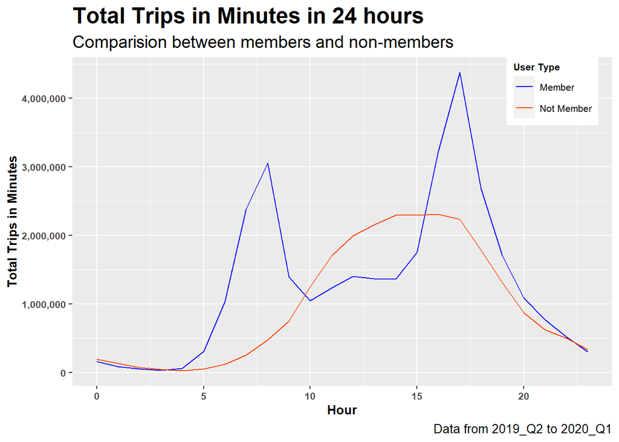

```r
# Graph labeling

graphM4<-  labs(title="Total Trips in Minutes in 24 hours",
                subtitle = "Comparision between members and non-members",
                caption = "Data from 2019_Q2 to 2020_Q1",
                x= "Hour",
                y ="Total Trips in Minutes",
                color="User Type")

# Line chart - Total Trips in Minutes in 24 hours

divvy_tips_2019_2020 %>%
  group_by(Hour, User_Type) %>%
  summarise(Total_Trip_Minutes =sum(Ride_Length_min)) %>%
  ggplot(mapping = aes(x=Hour, y=Total_Trip_Minutes,
                       group=User_Type, color=User_Type))+
  geom_line()+
  scale_y_continuous(label = scales::comma)+
  scale_color_manual(values = c("blue","orangered"))+
  scale_size_manual(values=c(1.5, 1.5))+
  graphM4+
  graphTh1+
  graphTh3
```

##### Members

1. The total number of trips and the pattern of full trips minutes in 24 hours are identical.

##### Not Members

1. Similarly, the total number of trips and full trips in 24 hours are identical.
2. However, the total minutes of trips utilized by a non-member are higher from 10 am to 3 pm than the member.
3. Based on the study, we could say that most of the members are likely from employee groups working in shifts.

#### Mean Trip Minutes in 24 hours

[output not shown]

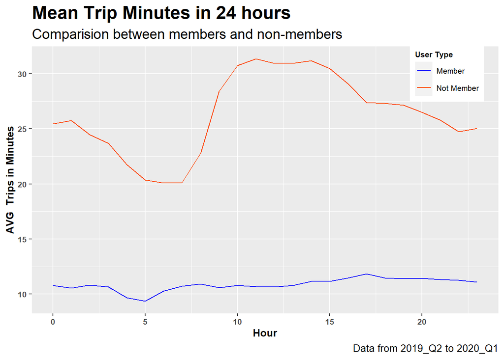

```r
# Graph labeling

graphM5<-  labs(title="Mean Trip Minutes in 24 hours",
                subtitle = "Comparision between members and non-members",
                caption = "Data from 2019_Q2 to 2020_Q1",
                x= "Hour",
                y ="AVG  Trips in Minutes",
                color="User Type")


# Line chart - Mean Trip Minutes in 24 hours

divvy_tips_2019_2020 %>%
  group_by(Hour, User_Type) %>%
  summarise(AVG_Trip_Minutes =mean(Ride_Length_min)) %>%
  ggplot(mapping = aes(x=Hour, y=AVG_Trip_Minutes,
                       group=User_Type, color=User_Type))+
  geom_line()+ scale_color_manual(values = c("blue","orangered"))+
  scale_size_manual(values=c(1.5, 1.5))+
  graphM5+
  graphTh1+
  graphTh3
```

##### Members

1. Mean trip time of member is in range of approximately from 9 to 11 thought the day.

##### Not Members

1. The mean trip time of non-member is deceased from 12 midnight to 6 am.
2. The sharp increase in mean trip time is observed after 7 am till 11 am. It remains steady till 2 pm and gradually decreases till 10 pm and slight increases after 10 pm.
3. Overall, mean trip time is higher by approximately two times with non-members compared with members. We will further deep-dive on the number of trips at various stations between members and non-members.

#### Number of Trips in Weekdays

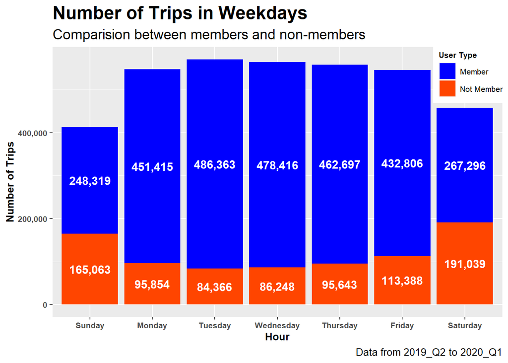

```r
# Graph labeling

graphM6<-  labs(title="Number of Trips in Weekdays",
                subtitle = "Comparision between members and non-members",
                caption = "Data from 2019_Q2 to 2020_Q1",
                x= "Hour",
                y ="Number of Trips",
                fill="User Type")
# Graph Theme

graphTh3<-theme(legend.position=c(0.93,0.90))

# stacked bar chart - Number of Trips in Weekdays

divvy_tips_2019_2020 %>%
  group_by(Day_Name,User_Type) %>%
  summarise(Total_rides_wk=n()) %>%
  ggplot(mapping = aes(x=Day_Name, y=Total_rides_wk,
                       fill=User_Type))+
  geom_bar(stat = "identity")+
  scale_y_continuous(label = scales::comma)+
  scale_fill_manual(values = c("blue","orangered"))+
  geom_text(aes(label = paste0(comma(round(Total_rides_wk,2)))),
            position = position_stack(vjust = .5),
            size=4,color="white", fontface="bold")+
  graphM6+
  graphTh1+
  graphTh3
```

##### Not Members

3. The number of trips was approximately 1.5 to 2.0 times higher on weekends than Monday-Friday.
4. The number of non-members’ trips was higher on Friday followed by Monday other than weekends.

#### Total Trips in Minutes in Weekdays

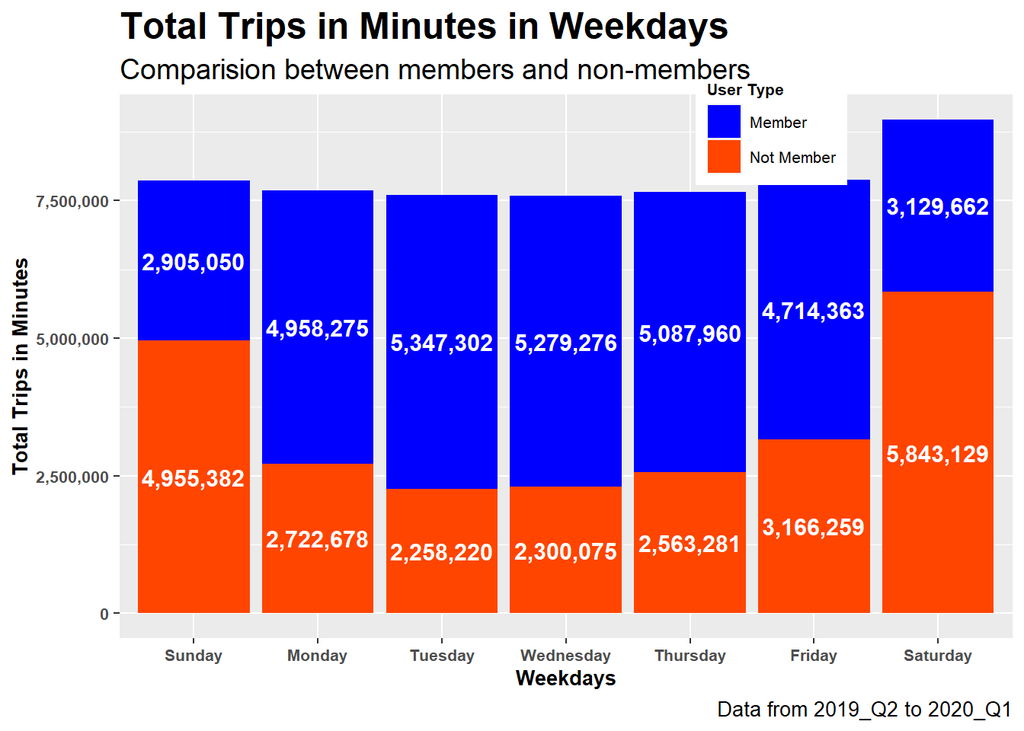

```r
# Graph labeling

graphM7<-  labs(title="Total Trips in Minutes in Weekdays",
                subtitle = "Comparision between members and non-members",
                caption = "Data from 2019_Q2 to 2020_Q1",
                x= "Weekdays",
                y ="Total Trips in Minutes",
                fill="User Type")

# Graph Theme

graphTh4<-theme(legend.position=c(0.73,0.94))

# stacked bar chart - Total Trips Minutes in Weekdays

divvy_tips_2019_2020 %>%
  group_by(Day_Name, User_Type) %>%
  summarise(Total_trips_min_wkd =sum(Ride_Length_min)) %>%
  ggplot(mapping=aes(x=Day_Name,y=Total_trips_min_wkd, fill=User_Type))+
  geom_bar(stat="identity")+
  scale_y_continuous(labels=scales::comma)+
  scale_fill_manual(values=c("blue","orangered"))+
  geom_text(aes(label = paste0(comma(round(Total_trips_min_wkd ,2)))),
          position = position_stack(vjust = .5),
          size=4,color="white",fontface="bold")+
  graphM7+
  graphTh1+
  graphTh4
```

##### Members

1. The maximum number of trips in minutes was higher on Tuesday and reduced gradually after Tuesday.
2. The lowest was on Sunday followed by Saturday.

##### Not Members

1. The maximum number of trips in minutes was higher on Saturday, followed by Sunday and Friday.
2. The trip utilization was observed higher on Friday, Saturday, and Sunday.

#### Mean Trip Minutes in Weekdays

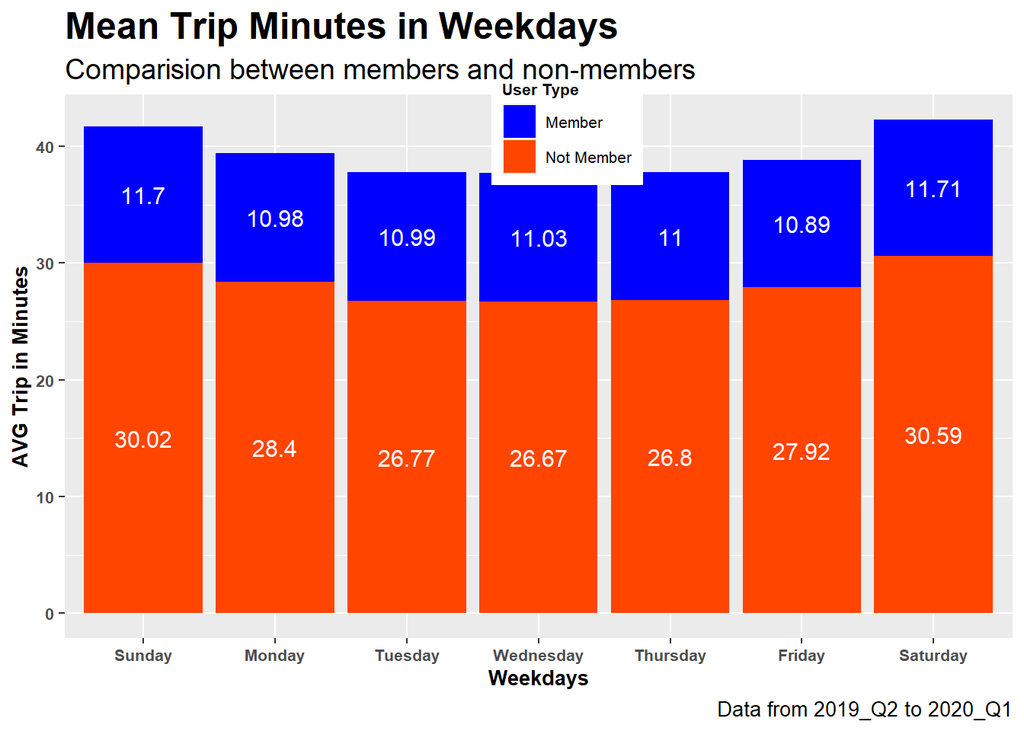

```r
# Graph labeling

graphM8<-labs(title="Mean Trip Minutes in Weekdays",
              subtitle = "Comparision between members and non-members",
              caption = "Data from 2019_Q2 to 2020_Q1",
              x= "Weekdays",
              y ="AVG Trip in Minutes",
              fill="User Type")

# Graph Theme

graphTh4<-theme(legend.position=c(0.53,0.94))

# stacked bar chart - Mean Trip Minutes in Weekdays

divvy_tips_2019_2020 %>%
  group_by(Day_Name,User_Type) %>%
  summarise(AVG_Trip_Min_wkd=mean(Ride_Length_min)) %>%
  ggplot(mapping = aes(x=Day_Name, y=AVG_Trip_Min_wkd,
                       fill=User_Type))+
  geom_bar(stat = "identity")+
  scale_fill_manual(values = c("blue","orangered"))+
  geom_text(aes(label= paste0(round(AVG_Trip_Min_wkd,2))),
            position = position_stack(vjust = 0.5),
            size=4,color="white")+
  graphM8 +
  graphTh1+
  graphTh4
```

##### Members

1. The mean trip in minutes is approximately two times lower than non-members.
2. Though the number of trips lowered on weekends, the average trips time is approximately higher by 1 minute.

##### Not Members

1. The mean trip in minutes is higher on Saturday and Sunday, followed by Monday and Friday.
2. Though the number of trips lowered compared with members, the average trip time in minutes is two times higher.

#### Number of Trips in Year-Month-Quarter

We created a Year-Month-Quarter column by

```r
# Create Year-Month Column

divvy_tips_2019_2020$Year_Month<-divvy_tips_2019_2020$Year*100+divvy_tips_2019_2020$Month_Number

# Check unqiue value of Year-Month Column and sort them

sort(unique(divvy_tips_2019_2020$Year_Month))
```

```
##  [1] 201904 201905 201906 201907 201908 201909 201910 201911 201912 202001
## [11] 202002 202003
```

```r
# Create Year-Month_ Quarter Column

divvy_tips_2019_2020$Year_Month_Quarter<-paste0(divvy_tips_2019_2020$Year_Month,divvy_tips_2019_2020$quarter_Number)

# Check unqiue value of Year-Month Column and sort them

sort(unique(divvy_tips_2019_2020$Year_Month_Quarter))
```

```
##  [1] "201904Q2" "201905Q2" "201906Q2" "201907Q3" "201908Q3" "201909Q3"
##  [7] "201910Q4" "201911Q4" "201912Q4" "202001Q1" "202002Q1" "202003Q1"
```

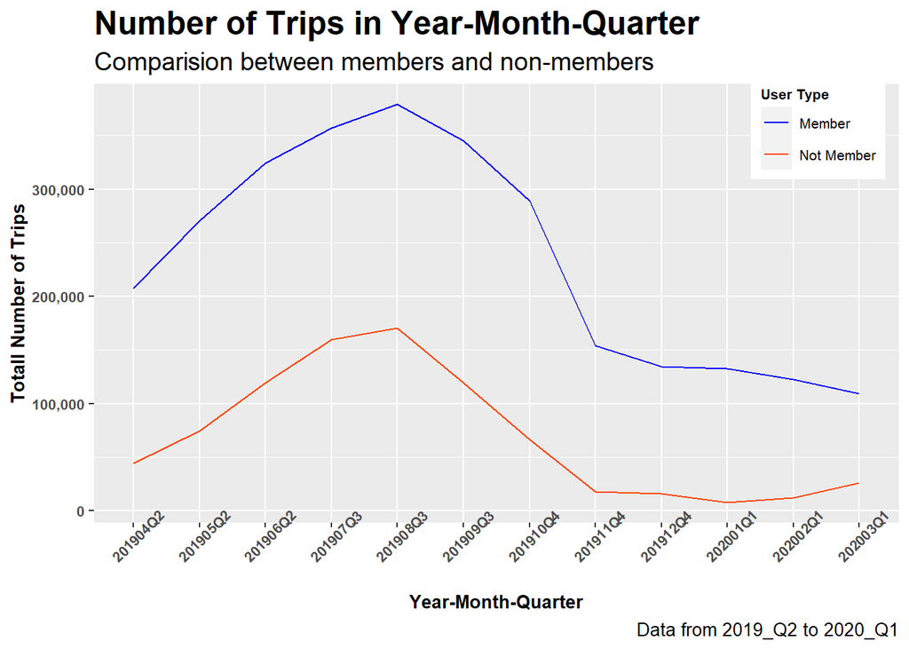

```r
# Graph labeling

graphM9<- labs(title="Number of Trips in Year-Month-Quarter",
               subtitle = "Comparision between members and non-members",
               caption = "Data from 2019_Q2 to 2020_Q1",
               x= "Year-Month-Quarter",
               y ="Totall Number of Trips",
               color="User Type")

# Graph Theme
graphTh5<-theme(legend.position=c(0.90,0.90),
                axis.text.x=element_text(size=8,face="bold",
                                         angle =45))

# Line chart - Number of Trips in Year-Month-Quarter

divvy_tips_2019_2020 %>%
  group_by(Year_Month_Quarter, User_Type) %>%
  summarise(Total_Number_Trips_ymq=n()) %>%
  ggplot(mapping = aes(x=Year_Month_Quarter,y=Total_Number_Trips_ymq,
                       group=User_Type,
                       color=User_Type))+
  geom_line()+
  scale_y_continuous(labels = scales::comma)+
  scale_color_manual(values = c("blue","orangered"))+
  scale_size_manual(values=c(1.5, 1.5))+
  graphM9 +
  graphTh1 +
  graphTh5
```

#### Total Trips in Minutes in Year-Month-Quarter

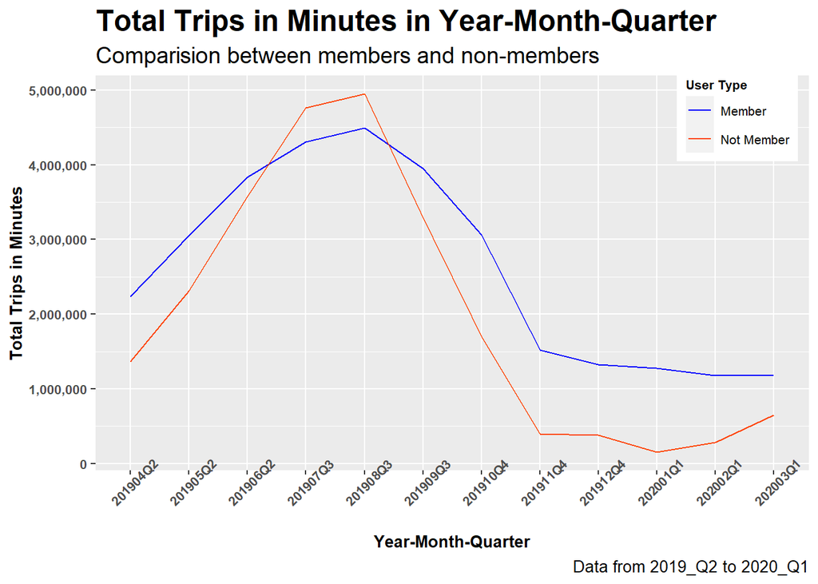

```r
graphM10<-  labs(title="Total Trips in Minutes in Year-Month-Quarter",
                 subtitle = "Comparision between members and non-members",
                 caption = "Data from 2019_Q2 to 2020_Q1",
                 x= "Year-Month-Quarter",
                 y ="Total Trips in Minutes",
                 color="User Type")

# Line chart - Total Trips in Minutes in Year-Month-Quarter

divvy_tips_2019_2020 %>%
  group_by(Year_Month_Quarter,User_Type) %>%
  summarise(Total_Ride_Mins_ymq= sum(Ride_Length_min)) %>%
  ggplot(mapping=aes(x=Year_Month_Quarter, y=Total_Ride_Mins_ymq,
                     group=User_Type,
                     color=User_Type))+
  geom_line()+
  scale_y_continuous(labels = scales::comma)+
  scale_color_manual(values = c("blue","orangered"))+
  scale_size_manual(values=c(1.5,1.5))+
  graphM10+
  graphTh1 +
  graphTh5
```

##### Members

1. A similar pattern for members was observed for total trip time in minutes as we followed the way in the total number of trips.
2. The trip time minutes reduced gradually from Aug 2019 till the end of September 2019. From September 2019, it was a steep decrease in total trip time till the end of Oct 2019. slightly decreased in whole trip minutes observed from November 2019 and remained steady from February to March 2020.

#### Mean Trips in Minutes in Year-Month-Quarter

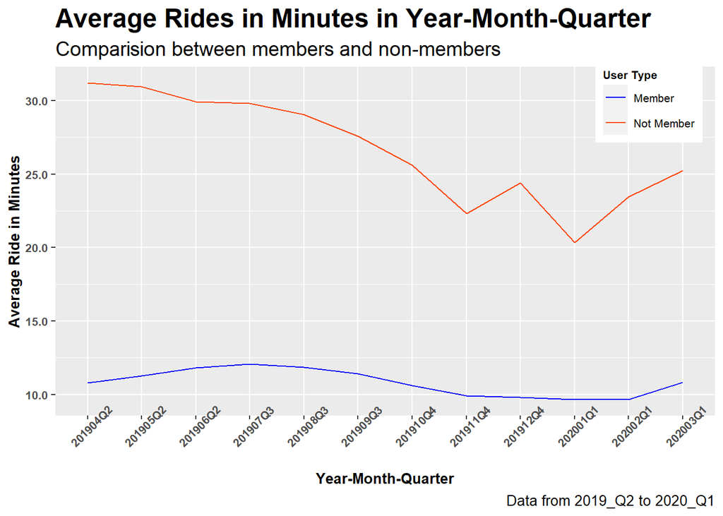

```r
# Graph labeling

graphM11<-  labs(title="Average Rides in Minutes in Year-Month-Quarter",
                 subtitle = "Comparision between members and non-members",
                 caption = "Data from 2019_Q2 to 2020_Q1",
                 x= "Year-Month-Quarter",
                 y ="Average Ride in Minutes",
                 color="User Type")

# Line Chart -  Mean Trips in Minutes in Year-Month-Quarter

divvy_tips_2019_2020 %>%
  group_by(Year_Month_Quarter,User_Type) %>%
  summarise(AVG_Ride_Min_ymq= mean(Ride_Length_min)) %>%
  ggplot(mapping=aes(x=Year_Month_Quarter, y=AVG_Ride_Min_ymq,
                     group=User_Type,
                     color=User_Type))+
  geom_line()+
  scale_y_continuous(labels = scales::comma)+
  scale_color_manual(values = c("blue","orangered"))+
  scale_size_manual(values=c(1.5,1.5))+
  graphM11 +
  graphTh1 +
  graphTh5
```

#### Number of Trips From Start Station

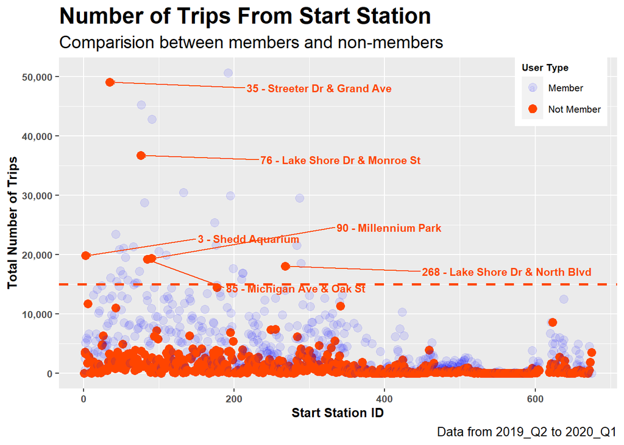

```r
# Graph labeling

graphM12<-  labs(title="Number of Trips From Start Station",
                 subtitle = "Comparision between members and non-members",
                 caption = "Data from 2019_Q2 to 2020_Q1",
                 x= "Start Station ID",
                 y ="Total Number of Trips",
                 color="User Type",
                 alpha="User Type")

# Line Chart -   Number of Trips From Start Station

divvy_tips_2019_2020 %>%
  group_by(Start_Station_ID, User_Type, Start_Station_Name) %>%
  summarise(Number_of_Trips_sid=n()) %>%
  ggplot(aes(x=Start_Station_ID, y=Number_of_Trips_sid,
                 group=User_Type,
                color=User_Type,
                alpha=User_Type)) +
  geom_point(size=3)+
  geom_text_repel(data=divvy_tips_2019_2020 %>%
             group_by(Start_Station_ID, User_Type, Start_Station_Name) %>%
             summarise(Number_of_Trips_sid=n()) %>%
             filter(User_Type=="Not Member", Number_of_Trips_sid>15000), # Filter data first
             aes(label=paste0(Start_Station_ID, " - ", Start_Station_Name)),
                 size=3, vjust=1.2, hjust=1.2, fontface ="bold",
                 arrow = arrow(length = unit(0.01, "npc")), box.padding = 1)+
  geom_hline(yintercept=15000,
             linetype="dashed", color = "orangered", size=1.0)+
  scale_y_continuous(labels = scales::comma)+
  scale_color_manual(values = c("blue","orangered"))+
  graphM12+
  graphTh1 + theme(legend.position=c(0.90,0.90),
                axis.text.x=element_text(size=8,face="bold"))
```

##### Not Members

The number of trips from non-members was higher than 15,000 trips at start station ID number [Name]:

1. 35-[Streeter Dr & Grand Ave];
2. 76-[Lake Shore Dr & Monroe St];
3. 90-[Millennium Park];
4. 85-[Michigan Ave & Oak St];
5. 3 -[Shedd Aquarium]; and
6. 268-[Lake Shore Dr & North Blvd]

Total trips “Not Members” were also higher when compared with the members at these station.

#### Total Trip in Minutes From Start Station

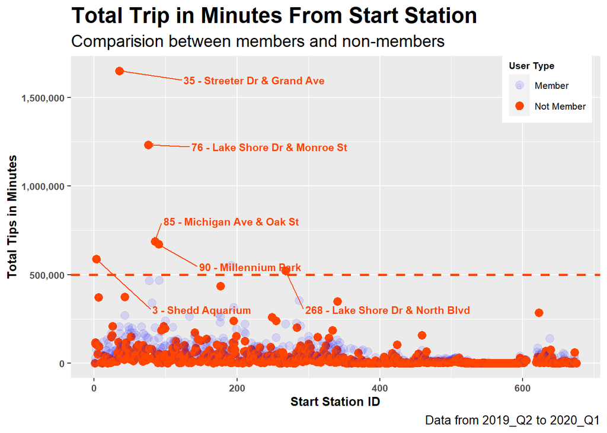

```r
# Graph labeling

graphM13<-  labs(title="Total Trip in Minutes From Start Station",
                 subtitle = "Comparision between members and non-members",
                 caption = "Data from 2019_Q2 to 2020_Q1",
                 x= "Start Station ID",
                 y ="Total Tips in Minutes",
                 color="User Type",
                 alpha="User Type")


# Line Chart -   Number of Trips From Start Station

divvy_tips_2019_2020 %>% group_by(Start_Station_ID,User_Type,Start_Station_Name) %>%
  summarise(Total_trip_Min_sid=sum(Ride_Length_min)) %>%
  ggplot(aes(x=Start_Station_ID,y=Total_trip_Min_sid,
      group=User_Type,
      color=User_Type,
      alpha=User_Type))+
  geom_point(size=3)+
  geom_hline(yintercept = 500000,linetype="dashed",
             color = "orangered", size=1.0)+
  geom_text_repel(data=divvy_tips_2019_2020 %>%
                    group_by(Start_Station_ID,User_Type,Start_Station_Name) %>%
                    summarise(Total_trip_Min_sid=sum(Ride_Length_min)) %>%
                    filter(User_Type=="Not Member", Total_trip_Min_sid>500000),
                  mapping = aes(x=Start_Station_ID,
                                y=Total_trip_Min_sid,
                                label=paste0(Start_Station_ID," - ", Start_Station_Name)),
                  size=3, vjust=0.8, hjust=1.2, fontface ="bold",
                 arrow = arrow(length = unit(0.01, "npc")), box.padding = 1)+
  scale_y_continuous(labels = scales::comma)+
  scale_color_manual(values = c("blue","orangered"))+
  graphM13+
  graphTh1 + theme(legend.position=c(0.90,0.90),
                axis.text.x=element_text(size=8,face="bold"))
```

##### Not Members

The total minutes trips from non-members was higher than 500,000 minutes at start station ID number [Name]:

1. 35 -[Streeter Dr & Grand Ave];
2. 76 -[Lake Shore Dr & Monroe St]; 3.90 -[Millennium Park];
3. 85 -[Michigan Ave & Oak St];
4. 3 -[Shedd Aquarium]; and
5. 268-[Lake Shore Dr & North Blvd]

Total minitues “Not Members” were also higher when compared with the members at these stations.

#### Concusion and reccomndation

The marketing team must focus on these stations to bring a non-member to membership and more promotions.

Note: Data was analyzed using R code and Excel PowerPoint. The Excel Power PowerPoint analysis file and ppt deck are attached to the data file. Thank you for your time to look into this analysis and report